# Time Series Analysis of Average Monthly PM2.5 in Detroit, Michigan

# Introduction

Particulate matter are particles of solids and liquids in the air that are able to be inhaled. These particles are also known as particle pollution and are indicators of air pollution. PM2.5 refers to particulate matter that is 2.5 microns or smaller in diameter. These particles generally come from pollutants that harm the environment from sources like industrial buildings, powerplants, and vehicles. [1] Those who inhale PM2.5 are at great risk for many health complications, such as respiratory irritation and airway corrosion. These complications have the potential to be deadly. [2] Reducing the amount of PM2.5 in the air is important for public health, especially during a pandemic of a respiratory illness, as well as for the health of the environment.

In our study, we are looking into the PM2.5 level in the Detroit, Michigan area over the the span of 22 years (from 2000-2022). Detroit is a large city with an even larger overall metropolitan area that is known as the birthplace of the automotive industry and still to this day contains many potential sources of PM2.5. The EPA claims that the PM2.5 concentration in the United States has been following a downward trend in this time. [3] We will investigate if this trend is the same for Detroit, attempt to fit a model to this data to best determine the overall trend of the data, and find the frequency pattern for this data.

With this analysis, we aim to answer the following questions:

- Whether or not PM 2.5 data in Detroit area contain seasonal variation and can thus be fitted by a SARIMA Model?
- Is there a consistent frequency pattern in PM 2.5 data in Detroit area from 2000 to 2022?

There have been other midterm projects for this course that have addressed PM2.5 trends in other locations. [4, 5] While those projects also looked at PM2.5, none used data from the United States. Additionally, we didn’t use these previous projects to guide our analysis, but we will comment on the differences and similarities between our findings and the findings of those other projects.

# Data Exploration

## Data Preparation

For our analysis, we are using data from the EPA, specifically measurements from all of the air quality monitoring sites in the Detroit area from 2000 to 2022. [6] We averaged the daily PM2.5 measurement from all of the monitoring sites each month to obtain the dataset that we are using. After doing this, we have 266 observations, each being the average PM2.5 measurement for that month.

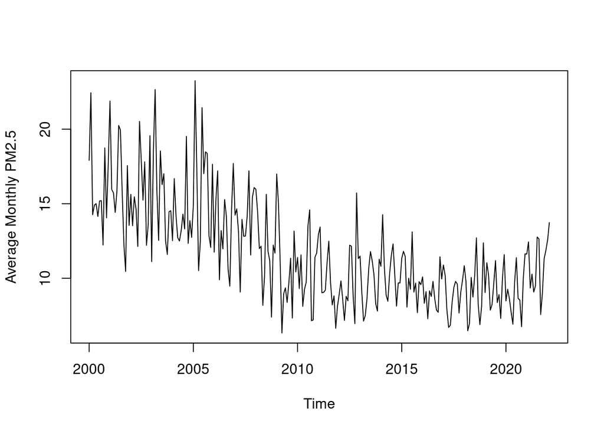

The plot above shows the time series of average monthly PM2.5 level in Detroit. The trend of the data appears to be showing a decline since the year 2000, meaning that PM2.5 levels in Detroit have gotten lower over time. Though from 2010 to 2020, PM2.5 levels do not appears to continue to decline. So, overall, this trend is consistent with the overall trend of PM2.5 in the United States that the EPA reported. [3]

## Decomposition Plots

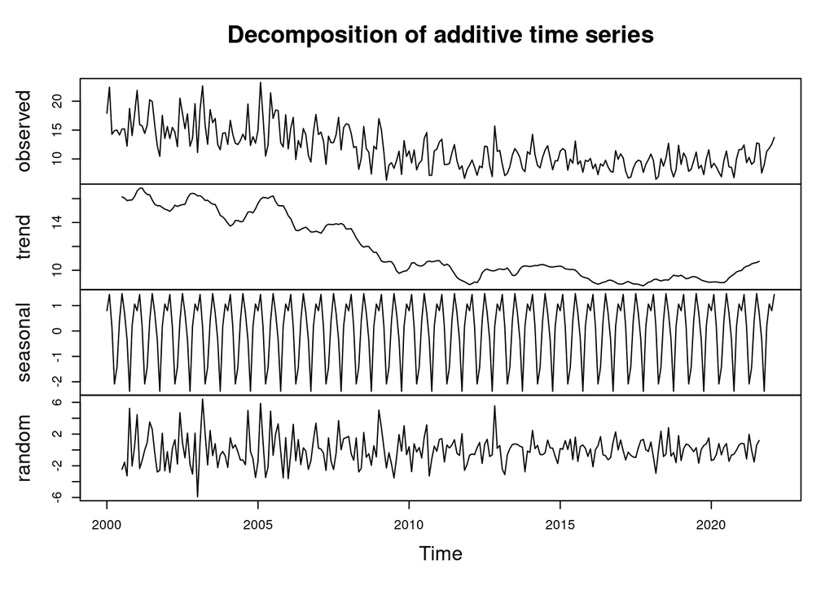

The decomposition plots above show a declining trend, as we previously observed. The seasonal plot indicates potential for seasonality. [7]

# Model selection and analysis

In this section, we want to find a time series model to fit the PM2.5 data, and make a prediction of monthly average PM2.5 levels in the following months.

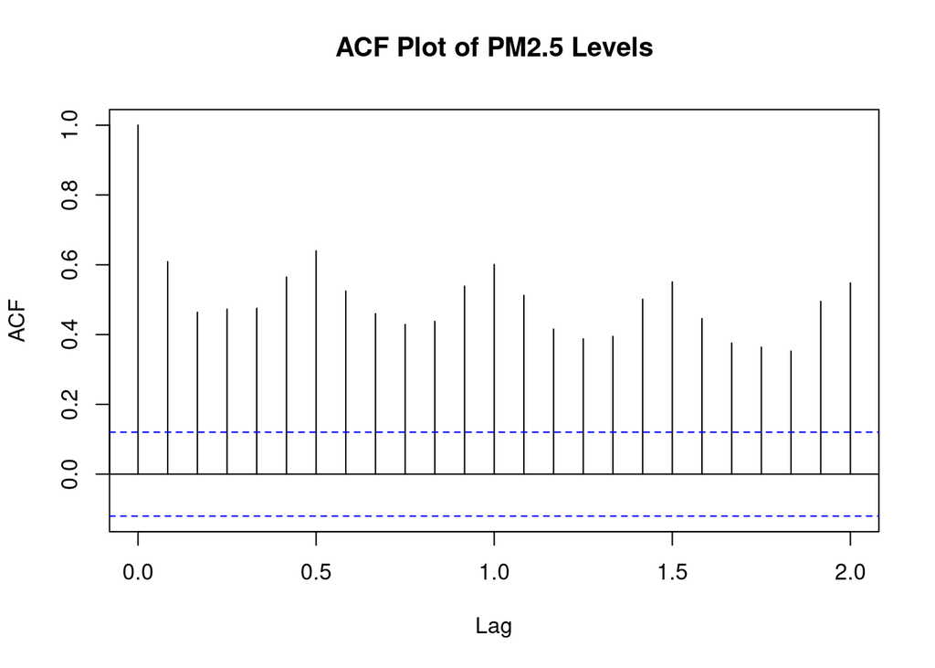

The ACF plot of monthly average PM2.5 plot also shows unstationary of the time series data. In order to make the data look more stationary for ARMA model fitting, we transform the data $y_{1:N}$ to $z_{2:N}$, where $y$ is the original monthly average PM2.5, and $z$ is the first difference of monthly average PM2.5. [8]

We calculate the first difference as the following:
$$z_n = \Delta y_n = y_n - y_{n-1}, n\in \{2,\cdots, N\}$$

## First difference

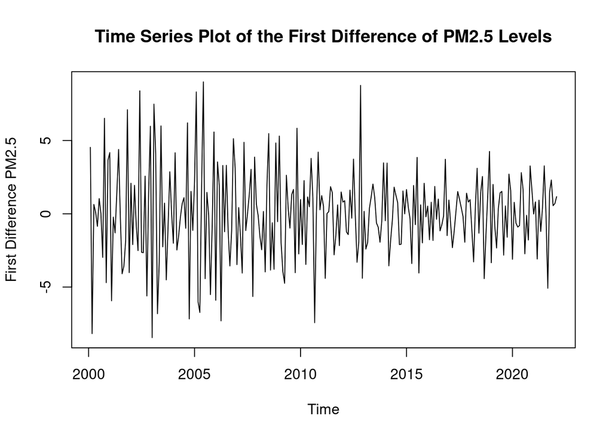

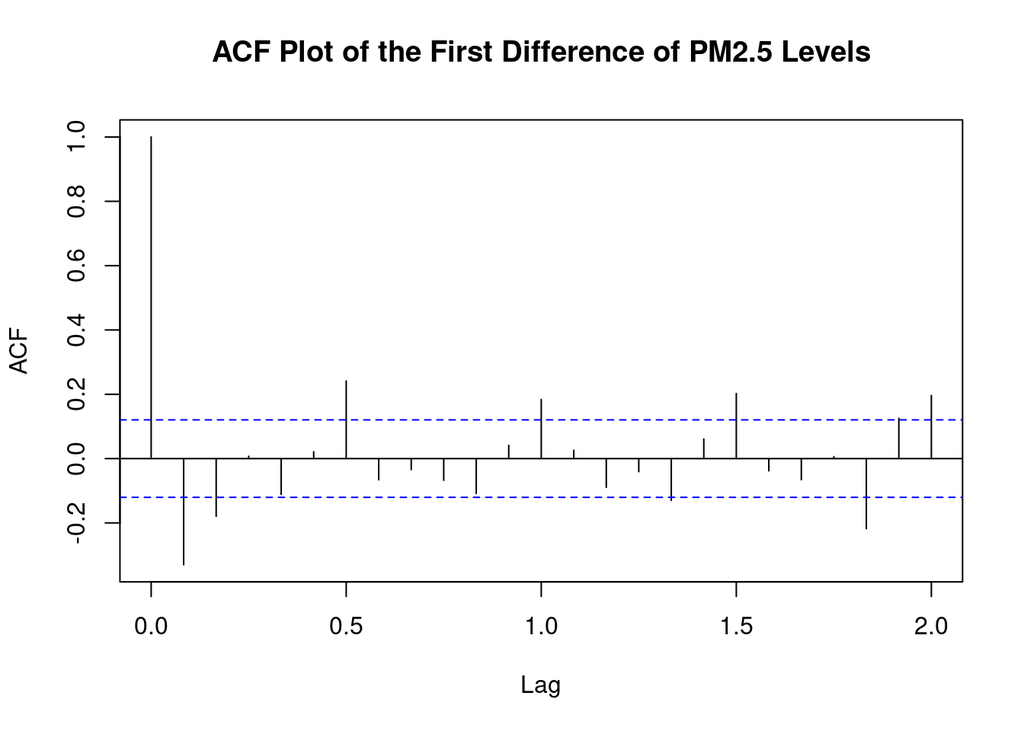

Both the time series plot and ACF plot show that the first difference data is stationary. Comparing with previous time series plot and ACF plot without first difference, data after first difference show more stationary than before.

## ARIMA model

We would fit a ARIMA($p,d,q$) model with $d=1$ using backshift operator $B$ as the following [8]:
$$\phi(B)[(1-B)^dY_n-\mu] = \psi(B)\epsilon_n$$
where
$$\begin{aligned}
\mu &= \mathbb{E}[X_n] \\
\phi(x) &= 1-\phi_1x-\phi_2x^2-\cdots-\phi_px^p \\
\psi(x) &= 1+\psi_1x+\psi_2x^2+\cdots+\psi_qx^q \\
\epsilon_n &\overset{\mathrm{iid}}{\sim}\mathcal{N}(\mu,\sigma^2)
\end{aligned}$$

To figure out the best $p$ and $q$ for first difference monthly average PM2.5 levels at Detroit area, we fit several ARIMA($p,1,q$) models for a range of $p$ and $q$, ranging from 0 to 3.

We use Akaike information criteria (AIC) as the standard for ARIMA model selection. AIC is derived as an approach to minimizing prediction error to make best model selection. The model with lowest AIC score is preferred. The formula of AIC is given by

$$AIC = -2\times\ell(\theta^*)+2D$$

where $\ell(\theta^*)$ is the maximum log likelihood, and $D$ is the number of parameters.

|  | MA0 | MA1 | MA2 | MA3 |
| --- | --- | --- | --- | --- |
| AR0 | 1348.56 | 1237.66 | 1230.74 | 1229.08 |
| AR1 | 1319.83 | 1233.16 | 1230.96 | 1229.03 |
| AR2 | 1292.60 | 1228.09 | 1227.29 | 1183.44 |
| AR3 | 1281.20 | 1228.19 | 1228.68 | 1185.21 |

Based on the AIC table of ARIMA models above, the best performed model with lowest AIC score is ARIMA(2, 1, 3) model. The AIC score for ARIMA(2, 1, 3) is 1183.44.

```
## Series: data
## ARIMA(2,1,3)
##
## Coefficients:
##          ar1      ar2      ma1     ma2      ma3
##       0.9979  -0.9996  -1.8808  1.8794  -0.8707
## s.e.  0.0027   0.0008   0.0365  0.0433   0.0334
##
## sigma^2 = 4.802:  log likelihood = -585.72
## AIC=1183.44   AICc=1183.77   BIC=1204.92
```

## SARIMA model

Since we are using monthly average as the data points, seasonal effect could not be ignored. Monthly seasonal ARIMA model may have a better fit. Similar to ARIMA model, SARIMA is a special case of ARIMA, where the AR, MA are factored into monthly polynomial in $B$ and seasonal polynomials in $B^k$, where $k$ is the period, along with updated differenced process$(1-B)^d(1-B^k)^DY_n$. The general SARIMA$(p,d,q)\times(P,D,Q)_{12}$ model for monthly data has the following form [9]:
$$\phi(B)\Phi(B^{12})[(1-B)^d(1-B^{12})^DY_n-\mu] = \psi(B)\Psi(B^{12})\epsilon_n$$
where
$$\begin{aligned}
\mu &= \mathbb{E}[X_n] \\
\phi(x) &= 1-\phi_1x-\phi_2x^2-\cdots-\phi_px^p \\
\psi(x) &= 1+\psi_1x+\psi_2x^2+\cdots+\psi_qx^q \\
\Phi(x) &= 1-\Phi_1x-\Phi_2x^2-\cdots-\Phi_px^P \\
\Psi(x) &= 1+\Psi_1x+\Psi_2x^2+\cdots+\Psi_qx^Q \\
\epsilon_n &\overset{\mathrm{iid}}{\sim}\mathcal{N}(\mu,\sigma^2)
\end{aligned}$$

Similar to finding the optimal $p$ and $q$ for ARIMA model, we will fit several SARIMA models based on ARIMA(2,1,3) for a range of $P$ and $Q$, ranging from 0 to 2. We also use AIC as the standard to select the optimal model.

|  | SMA0 | SMA1 | SMA2 |
| --- | --- | --- | --- |
| SAR0 | 1183.44 | 1185.16 | 1184.45 |
| SAR1 | 1200.89 | 1181.24 | 1183.09 |
| SAR2 | 1210.11 | 1191.63 | 1184.84 |

Based on the AIC table of seasonal ARIMA model above, the best performed model with lowest AIC score is 1181.245, where seasonal AR=1, seasonal MA=1. Hence, our optimal SARIMA model is SARIMA$(2,1,3)\times(1,0,1)_{12}$

```
## Series: data
## ARIMA(2,1,3)(1,0,1)[12]
##
## Coefficients:
##           ar1      ar2     ma1      ma2      ma3    sar1     sma1
##       -1.5014  -0.9739  0.6731  -0.3783  -0.8847  0.9978  -0.9595
## s.e.   0.0167   0.0177  0.0366   0.0535   0.0367  0.0099   0.0900
##
## sigma^2 = 4.456:  log likelihood = -582.62
## AIC=1181.24   AICc=1181.81   BIC=1209.88
```

The AIC score for the optimal ARIMA model is 1183.44, and the one for the optimal SARIMA model is 1181.24. The difference between AIC score is not much so we actually may not tell the difference between two models. We need further test to tell whether two models are different. We adopt a likelihood ratio tests for nested hypothesis [10]:

$$\begin{aligned}
H^{<0>}:\theta\in\Theta^{<0>} &= (\mu,\sigma^2,\phi_{1:2},\psi_{1:3}) \\
H^{<1>}:\theta\in\Theta^{<1>} &= (\mu,\sigma^2,\phi_{1:2},\psi_{1:3},\Phi_1,\Psi_1) \\
\ell^{<1>}-\ell^{<0>} & \approx \frac{1}{2}\chi^2_{D^{<1>}-D^{<0>}}
\end{aligned}$$

where

$$\begin{aligned}
\ell^{<0>} &= \sup_{\theta\in\Theta^{<0>}}\ell(\theta) \\
\ell^{<1>} &= \sup_{\theta\in\Theta^{<1>}}\ell(\theta)
\end{aligned}$$
And $D$ is the dimension for each hypothesis.

```r
diff_log = sarima213101$loglik - arima213$loglik
diff_chisq = 0.5*qchisq(0.95, df=3)
print(diff_log>diff_chisq)
```

```
## [1] FALSE
```

## Diagnostics

We make a comparison between the raw data of PM2.5 level (black line) and the fitted values using ARIMA(2,1,3) model (red line). [11] It shows that the fitted values have the same trend as the raw data, but with smaller volatility. The residual plot shows that residuals are roughly symmetry about 0, in accordance with the zero mean assumption.

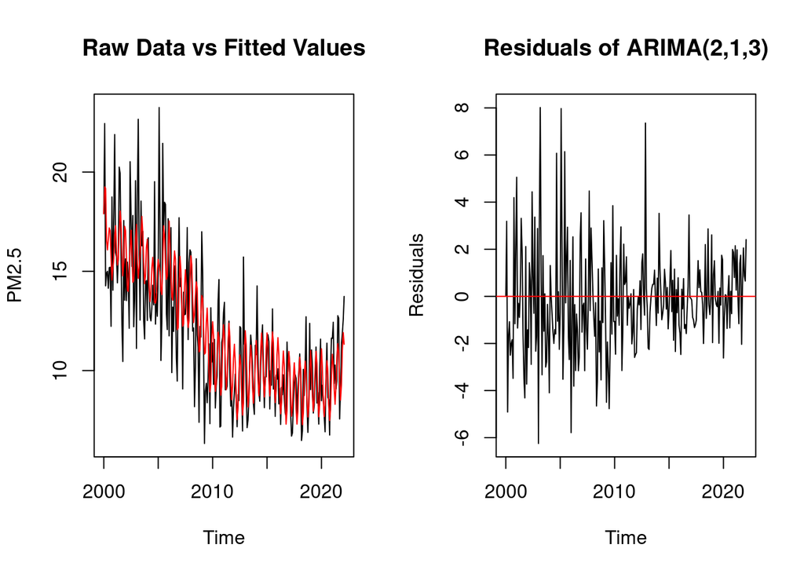

The ACF plot of residuals of ARIMA(2, 1, 3) model shows that the $\epsilon_n$ follows our assumption of white noise since all lags are fallen between the dashed lines. The qqplot of residuals of ARIMA(2, 1, 3) model shows a little heavier tail than the normal, given most points are falling around the qqline. In general, we agree that the residuals of ARIMA(2, 1, 3) follows the mean zero normal distributed assumption.

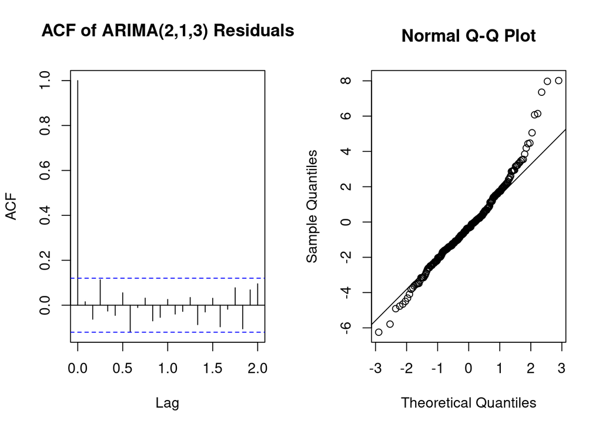

## Prediction

We make some future prediction of monthly average PM2.5 levels at Detroit area based on the ARIMA(2,1,3) model we built. [12]

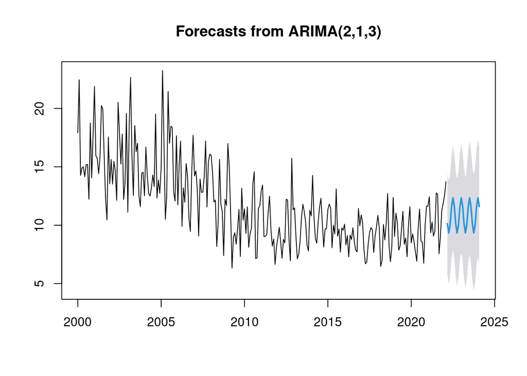

We can tell that the trend of PM2.5 levels are fluctuated in the range from 9 to 12. The fluctuation has a period of 6 months. However, the range of 95% confidence interval of the prediction value is large (ranging from 5 to 17) and we cannot explain why the wide range CI based on our analysis so far.

# Frequency Pattern Analysis

We are interested in finding the frequency pattern of PM 2.5 in Detroit area.

## Fourier Analysis

First, we use Fourier analysis to find the frequency domain throughout 2000-2022 in general.

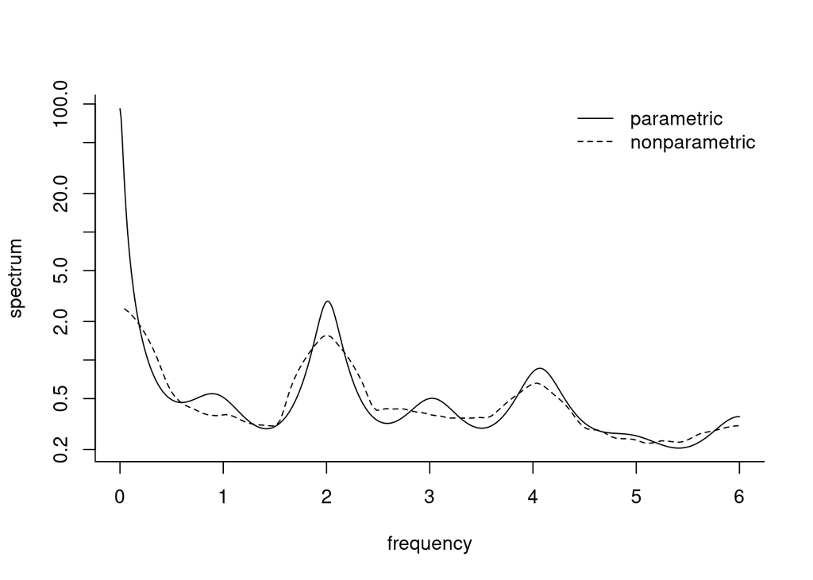

```
## [1] "Maximum spectrum in the parametric periodogram at frequency 0"
```

```
## [1] "Maximum spectrum in the non-parametric periodogram at frequency 0.0444444444444444"
```

## Wavelet Analysis

Fourier analysis assumes that the frequency throughout the entire time interval of the data is constant, whereas that’s certainly not the case for the PM2.5 data in Detroit area from 2000 to 2022. To examine the different frequency patterns before and after 2010, we will introduce wavelet analysis. Wavelet utilizes the formula
$$\lambda(a,\tau)=\frac{1}{\sqrt{a}}\int_{\infty}^\infty \gamma(x)\psi(\frac{x-\tau}{a})dt$$
for different choice of wave functions $\psi(x)$, where $a$ is the scale controlling the stretch extension of the wave function and $\tau$ is the translation parameter controlling the movement of the wave function in the scope of time. [17] The wave function we use [18] is
$$\psi(x)=\pi^{-\frac{1}{4}}e^{i\omega x}e^{-\frac{-x^2}{2}}$$
Instead of converting raw data into the frequency domain, wavelet transformation converts data into the frequency and time domains, such that we can analyze the frequency patterns within the scope of time.

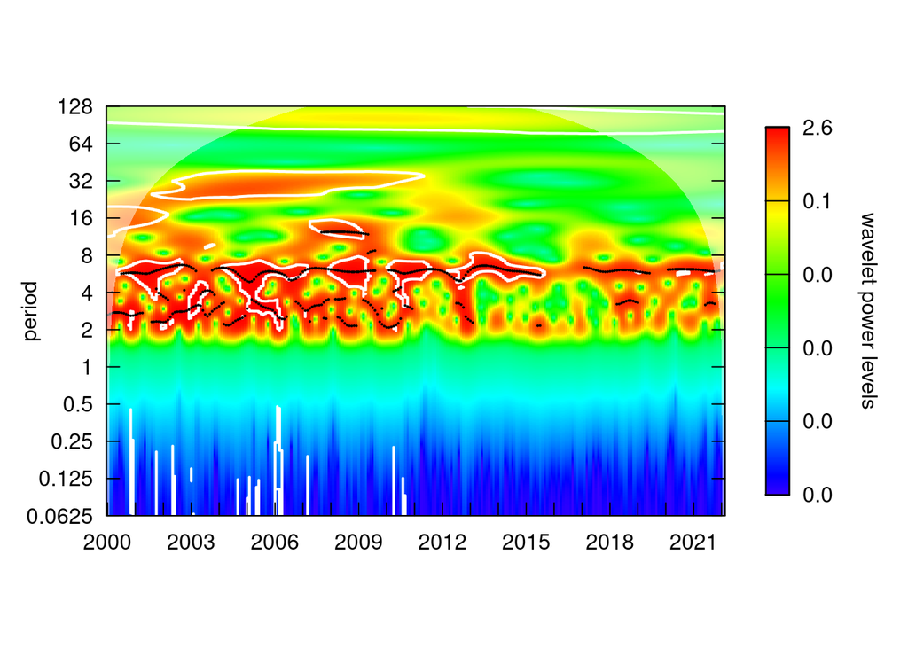

# Discussion

# Conclusion

The average monthly PM2.5 level in the Detroit area has been decreasing from 2000 to 2022, which follows the national trend. We found the best model for monthly average PM2.5 levels in Detroit to be an ARIMA(2, 1, 3) model after comparing with a SARIMA(2, 1, 3) and finding no meaningful difference between the two. This leads us to conclude that there is no meaningful seasonality in our Detroit PM2.5 data.

From the ARIMA(2, 1, 3) output, we find that the final formula for this model is:

# Sources

1. https://www.epa.gov/pm-pollution/particulate-matter-pm-basics
2. https://www.ncbi.nlm.nih.gov/pmc/articles/PMC4740125/
3. https://www.epa.gov/air-trends/particulate-matter-pm25-trends
4. Previous midterm project on PM2.5 https://ionides.github.io/531w21/midterm_project/project14/project.html
5. Previous midterm project on PM2.5 https://ionides.github.io/531w21/midterm_project/project12/project.html
6. Data: https://www.epa.gov/outdoor-air-quality-data/download-daily-data (The data compilation process was detailed in the introduction section)
7. https://rpubs.com/davoodastaraky/TSA1
8. STATS 531 Lecture Notes, Chapter 6, P11
9. STATS 531 Lecture Notes, Chapter 6, P15
10. Lecture Notes, Chapter 5 Parameter estimation and model identification for ARMA models, Likelihood ratio tests for nested hypotheses, P18
11. Stats531, W21, Midterm Project, . US Candy Production Data, https://ionides.github.io/531w21/midterm_project/project02/project.html
12. W. Wang and Y. Guo, “Air Pollution PM2.5 Data Analysis in Los Angeles Long Beach with Seasonal ARIMA Model,” 2009 International Conference on Energy and Environment Technology, 2009, pp. 7-10, doi: 10.1109/ICEET.2009.468.
13. STATS 531 Lecture Slides, Chapter 7, P10
14. STATS 531 Lecture Slides, Chapter 4, P5
15. Spectral estimation in R https://lbelzile.github.io/timeseRies/spectral-estimation-in-r.html#smoothing-and-seasonally-adjusted-values
16. STATS 531 Lecture Slides, Chapter 5, P21
17. K. Wirsing (2020). Wavelet Theory. Ch.5 Continuous wavelet. https://www.intechopen.com/chapters/74096
18. WaveletComp 1.1:A guided tour through the R package. https://cran.r-project.org/web/packages/WaveletComp
19. Previous midterm projects (used for reference on what this project generally should look like) https://ionides.github.io/531w21/midterm_project/
20. Detrending in Time Series in R. https://koalatea.io/r-detrending-time-series/